# Project: Investigating Medical Appointments.

- Introduction
- Data Wrangling
- Exploratory Data Analysis
- Conclusions

## Introduction

### Data:

> Medical appointments described with 14 variables including whether the person attended or missed the appointment.

##### variables:

> PatientId  
> AppointmentID  
> Gender  
> ScheduledDay  
> AppointmentDay  
> Age  
> Neighbourhood  
> Scholarship  
> Hipertension  
> Diabetes  
> Alcoholism  
> Handcap  
> SMS_received  
> No-show

### Questions:

> 1- is there any co-relation between the attendance and the Age or gender of the person?  
> 2- is there any co-relation between the attendance and the medical condition of the person, that includes (Hipertension, Diabetes, Alcoholism, Handicap)?  
> 3- is reminding the patient with an SMS helps?  
> 4- what effect does the scholarship have?  
> 5- how different is the medical profile of people who attend and who don't?  
> 6- what effect does the duration between Scheduling and the actucal date have?  
> 7- does the day on which the appointment is scheduled make a difference?  
> 8- what effect does the Neighbourhood have?

```python
import pandas as pd
import numpy as np
import matplotlib.pyplot as plt
import seaborn as sns
%matplotlib inline
import datetime
sns.set_style('darkgrid')
```

## Data Wrangling

> Exploring Data:

### General Properties

```python
df = pd.read_csv('noshowappointments-kagglev2-may-2016.csv') #reading file and creating dataframe.
df.head()
```

|  | PatientId | AppointmentID | Gender | ScheduledDay | AppointmentDay | Age | Neighbourhood | Scholarship | Hipertension | Diabetes | Alcoholism | Handcap | SMS_received | No-show |
| --- | --- | --- | --- | --- | --- | --- | --- | --- | --- | --- | --- | --- | --- | --- |
| 0 | 2.987250e+13 | 5642903 | F | 2016-04-29T18:38:08Z | 2016-04-29T00:00:00Z | 62 | JARDIM DA PENHA | 0 | 1 | 0 | 0 | 0 | 0 | No |
| 1 | 5.589978e+14 | 5642503 | M | 2016-04-29T16:08:27Z | 2016-04-29T00:00:00Z | 56 | JARDIM DA PENHA | 0 | 0 | 0 | 0 | 0 | 0 | No |
| 2 | 4.262962e+12 | 5642549 | F | 2016-04-29T16:19:04Z | 2016-04-29T00:00:00Z | 62 | MATA DA PRAIA | 0 | 0 | 0 | 0 | 0 | 0 | No |
| 3 | 8.679512e+11 | 5642828 | F | 2016-04-29T17:29:31Z | 2016-04-29T00:00:00Z | 8 | PONTAL DE CAMBURI | 0 | 0 | 0 | 0 | 0 | 0 | No |
| 4 | 8.841186e+12 | 5642494 | F | 2016-04-29T16:07:23Z | 2016-04-29T00:00:00Z | 56 | JARDIM DA PENHA | 0 | 1 | 1 | 0 | 0 | 0 | No |

```python
df.tail()
```

|  | PatientId | AppointmentID | Gender | ScheduledDay | AppointmentDay | Age | Neighbourhood | Scholarship | Hipertension | Diabetes | Alcoholism | Handcap | SMS_received | No-show |
| --- | --- | --- | --- | --- | --- | --- | --- | --- | --- | --- | --- | --- | --- | --- |
| 110522 | 2.572134e+12 | 5651768 | F | 2016-05-03T09:15:35Z | 2016-06-07T00:00:00Z | 56 | MARIA ORTIZ | 0 | 0 | 0 | 0 | 0 | 1 | No |
| 110523 | 3.596266e+12 | 5650093 | F | 2016-05-03T07:27:33Z | 2016-06-07T00:00:00Z | 51 | MARIA ORTIZ | 0 | 0 | 0 | 0 | 0 | 1 | No |
| 110524 | 1.557663e+13 | 5630692 | F | 2016-04-27T16:03:52Z | 2016-06-07T00:00:00Z | 21 | MARIA ORTIZ | 0 | 0 | 0 | 0 | 0 | 1 | No |
| 110525 | 9.213493e+13 | 5630323 | F | 2016-04-27T15:09:23Z | 2016-06-07T00:00:00Z | 38 | MARIA ORTIZ | 0 | 0 | 0 | 0 | 0 | 1 | No |
| 110526 | 3.775115e+14 | 5629448 | F | 2016-04-27T13:30:56Z | 2016-06-07T00:00:00Z | 54 | MARIA ORTIZ | 0 | 0 | 0 | 0 | 0 | 1 | No |

```python
df.shape
```

```
(110527, 14)
```

> Data consists of 110527 rows and 14 columns

```python
df.info() #checking data types.
```

```
<class 'pandas.core.frame.DataFrame'>
RangeIndex: 110527 entries, 0 to 110526
Data columns (total 14 columns):
 #   Column          Non-Null Count   Dtype
---  ------          --------------   -----
 0   PatientId       110527 non-null  float64
 1   AppointmentID   110527 non-null  int64
 2   Gender          110527 non-null  object
 3   ScheduledDay    110527 non-null  object
 4   AppointmentDay  110527 non-null  object
 5   Age             110527 non-null  int64
 6   Neighbourhood   110527 non-null  object
 7   Scholarship     110527 non-null  int64
 8   Hipertension    110527 non-null  int64
 9   Diabetes        110527 non-null  int64
 10  Alcoholism      110527 non-null  int64
 11  Handcap         110527 non-null  int64
 12  SMS_received    110527 non-null  int64
 13  No-show         110527 non-null  object
dtypes: float64(1), int64(8), object(5)
memory usage: 11.8+ MB
```

```python
df.isnull().sum()#finding NaN values.
```

```
PatientId         0
AppointmentID     0
Gender            0
ScheduledDay      0
AppointmentDay    0
Age               0
Neighbourhood     0
Scholarship       0
Hipertension      0
Diabetes          0
Alcoholism        0
Handcap           0
SMS_received      0
No-show           0
dtype: int64
```

```python
df.duplicated().sum() #checking duplicated values.
```

```
0
```

No NaN values or duplicated rows.

```python
type(df['AppointmentDay'][0]) #data type check.
```

```
str
```

```python
type(df['ScheduledDay'][0]) #data type check.
```

```
str
```

```python
df.describe()
```

|  | PatientId | AppointmentID | Age | Scholarship | Hipertension | Diabetes | Alcoholism | Handcap | SMS_received |
| --- | --- | --- | --- | --- | --- | --- | --- | --- | --- |
| count | 1.105270e+05 | 1.105270e+05 | 110527.000000 | 110527.000000 | 110527.000000 | 110527.000000 | 110527.000000 | 110527.000000 | 110527.000000 |
| mean | 1.474963e+14 | 5.675305e+06 | 37.088874 | 0.098266 | 0.197246 | 0.071865 | 0.030400 | 0.022248 | 0.321026 |
| std | 2.560949e+14 | 7.129575e+04 | 23.110205 | 0.297675 | 0.397921 | 0.258265 | 0.171686 | 0.161543 | 0.466873 |
| min | 3.921784e+04 | 5.030230e+06 | -1.000000 | 0.000000 | 0.000000 | 0.000000 | 0.000000 | 0.000000 | 0.000000 |
| 25% | 4.172614e+12 | 5.640286e+06 | 18.000000 | 0.000000 | 0.000000 | 0.000000 | 0.000000 | 0.000000 | 0.000000 |
| 50% | 3.173184e+13 | 5.680573e+06 | 37.000000 | 0.000000 | 0.000000 | 0.000000 | 0.000000 | 0.000000 | 0.000000 |
| 75% | 9.439172e+13 | 5.725524e+06 | 55.000000 | 0.000000 | 0.000000 | 0.000000 | 0.000000 | 0.000000 | 1.000000 |
| max | 9.999816e+14 | 5.790484e+06 | 115.000000 | 1.000000 | 1.000000 | 1.000000 | 1.000000 | 4.000000 | 1.000000 |

> Ages of zero and -1 indicate a pregnant woman and babies.

### Data Cleaning:

> 1- AppointmentDay and ScheduledDay are to be datetime format.  
> 2- the time component of the AppointmentDay is missing so we need to ignore that component in the ScheduledDay in order to make the data consistent and to extract a consistent waiting time, then we are dropping the two columns.  
> 3- subtract the two dates to get the waiting time for each patient.  
> 4- there are columns need to be ranamed: No-show to Attendance, Handcap to Handicap, Hipertension to Hypertension.  
> 5- the new attendance column will be better understood if we replaced the Yes and NO values with ones and zeros.. note that the No meant that the patient did really attend.  
> 6- Age categories are important as ages are too many and creating categories would ease the analysis to some extend.  
> 7- patient ID and appointment ID are irrelevant to the analysis so we will drop them.

```python
df['ScheduledDay']=pd.to_datetime(df['ScheduledDay']) #converting to datetime
df['AppointmentDay']=pd.to_datetime(df['AppointmentDay'])
```

```python
df['ScheduledDay']= df['ScheduledDay'].apply(lambda x: x.strftime('%D')) #getting only the date portion of the value.
df['AppointmentDay']= df['AppointmentDay'].apply(lambda x: x.strftime('%D')) #getting only the date portion of the value.
df['AppointmentDay']=pd.to_datetime(df['AppointmentDay'])
df['ScheduledDay']=pd.to_datetime(df['ScheduledDay'])
```

```python
df['WeekDay']=df['AppointmentDay'].apply(lambda x: x.strftime('%A')) #extracting the day of the week.
```

```python
df['WaitingTime']=df['AppointmentDay'] - df['ScheduledDay'] #getting waiting time
df['WaitingTime'].describe()
```

```
count                        110527
mean     10 days 04:24:31.828602965
std      15 days 06:07:11.673762786
min               -6 days +00:00:00
25%                 0 days 00:00:00
50%                 4 days 00:00:00
75%                15 days 00:00:00
max               179 days 00:00:00
Name: WaitingTime, dtype: object
```

```python
waiting_prob= df[df['WaitingTime'] < "0 days "] #checking for waiting times that are not possible
```

```python
df.drop(waiting_prob.index,inplace=True) #droping those values.
```

```python
df['WaitingTime']=df['WaitingTime'].apply(lambda x: x.days) #extracting the number of days only.
```

```python
df.rename(columns={'No-show':'Attendance','Handcap':'Handicap','Hipertension':'Hypertension'},inplace=True) #renaming columns.
```

```python
df['Attendance']= df['Attendance'].replace({'No':1,'Yes':0}) #changing values
```

```python
df.drop(['PatientId','AppointmentID','ScheduledDay','AppointmentDay'],axis=1,inplace=True) #dropping unimportant columns.
```

```python
age_bins=[-2,-1,10,20,30,40,50,60,70,80,90,100,110,120] #creating categories from numerical values of age.
age_cat=['pregnant woman',"baby-10","10-20",'20-30','30-40','40-50','50-60','60-70','70-80','80-90','90-100','100-110','110-120']
df['Age categories']=pd.cut(df['Age'],age_bins,labels=age_cat)
df[(df['Age']==-1)]
```

|  | Gender | Age | Neighbourhood | Scholarship | Hypertension | Diabetes | Alcoholism | Handicap | SMS_received | Attendance | WeekDay | WaitingTime | Age categories |
| --- | --- | --- | --- | --- | --- | --- | --- | --- | --- | --- | --- | --- | --- |
| 99832 | F | -1 | ROMÃO | 0 | 0 | 0 | 0 | 0 | 0 | 1 | Monday | 0 | pregnant woman |

```python
df['Handicaped']=df['Handicap'].replace({2:1,3:1,4:1}) #creating new column for handicapabilty.
```

## Exploratory Data Analysis

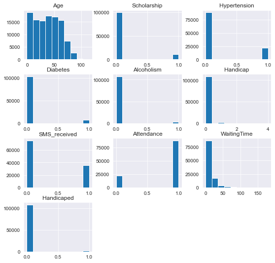

```python
df.hist(figsize=(9,9));
```

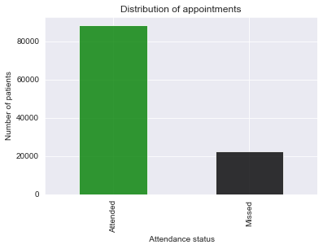

```python
df['Attendance'].value_counts().plot(kind='bar',color=['green','black'],title='showed up vs missed',alpha=.8); #plotting number of appointments missed vs attended.
plt.xticks([0,1],['Attended','Missed']);
plt.xlabel(' Attendance status');
plt.ylabel('Number of patients');
plt.title('Distribution of appointments');
```

> Clearly the Number of patients attended their appointments is far more than who missed

### Question 1: is there any co-relation between the attendance and the Age or gender of the person?

#### First Gender:

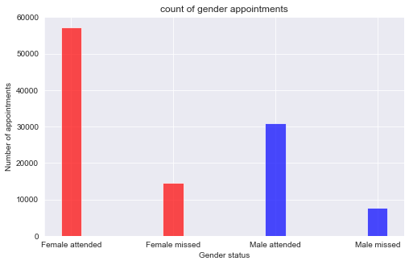

```python
gender_data=df.groupby('Gender')['Attendance'].value_counts()
plt.figure(figsize=(8,5));
plt.bar(['Female attended','Female missed','Male attended','Male missed'],gender_data.values,color=['red','red','blue','blue'],alpha=.7,width=.2);#plotting number of appointments missed vs attended by both sexes.
plt.title('count of gender appointments');
plt.xlabel('Gender status');
plt.ylabel('Number of appointments');
```

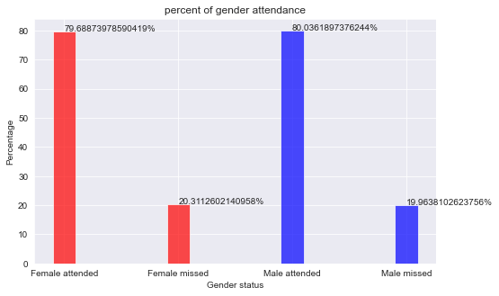

```python
plt.figure(figsize=(8,5))
a=['Female attended','Female missed','Male attended','Male missed']
b=df.groupby('Gender')['Attendance'].value_counts(normalize=True)*100
plt.bar(a,b,color=['red','red','blue','blue'],alpha=.7,width=.2) ##plotting percentage of appointments missed vs attended by both sexes.
plt.title('percent of gender attendance')
plt.xlabel('Gender status')
plt.ylabel('Percentage')
for index, value in zip(a,b):
    plt.text(index,value,str(value)+"%")
```

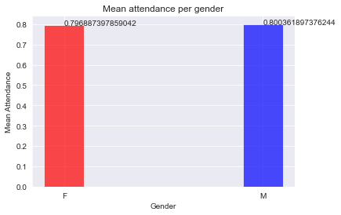

```python
gender_mean=df.groupby('Gender')['Attendance'].mean()
x=gender_mean.index
y=gender_mean.values
plt.bar(x,y,color=['red','blue'],alpha=.7,width=.2); #plotting mean attendance.
plt.xlabel('Gender')
plt.ylabel('Mean Attendance')
plt.title('Mean attendance per gender')
for value, index in zip(y,x):
    plt.text(index,value,str(value))
```

> Although Females has the larger number of appointments, Males has a slightly higher attendance percetage among their peers and overall slightly higher attendance mean.

#### Second: Age:

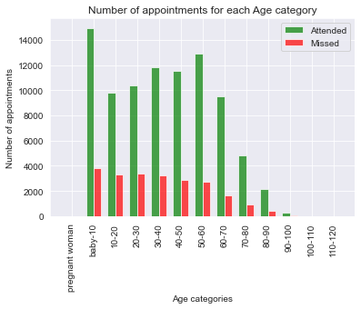

```python
df1=df[df['Attendance']==1] #creating a df for people who attended.
df0=df[df['Attendance']==0] #creating a df for people who missed.
one=( df1.groupby('Age categories')['Attendance'].count()).values
zero=( df0.groupby('Age categories')['Attendance'].count()).values
ind=np.arange(13)
width=.35
#plotting both in the same graph.
plt.bar(ind, one, width, color='green', alpha=.7, label='Attended');
plt.bar(ind + width, zero, width, color='r', alpha=.7, label='Missed');
locations = ind + width / 2
labels =  ['pregnant woman', 'baby-10', '10-20', '20-30', '30-40',
                  '40-50', '50-60', '60-70', '70-80', '80-90', '90-100',
                  '100-110', '110-120'];
plt.xticks(locations, labels,rotation='vertical');
plt.xlabel('Age categories');
plt.ylabel('Number of appointments');
plt.title('Number of appointments for each Age category');
plt.legend();
```

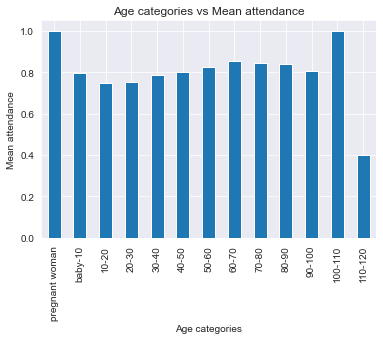

```python
df.groupby('Age categories')['Attendance'].mean().plot(kind='bar'); #plotting mean attendance vs age cats.
plt.ylabel('Mean attendance');
plt.xlabel('Age categories');
plt.title('Age categories vs Mean attendance');
```

> - Mean attendance for the pregnant woman and the group fro, 100-110 is one due to the lack of data (only one pregnant woman).  
>   -The distribution of means in the middle shows that from ages 10 to 70 people tend not to miss this appointments more as they grow up, then the means falls as they get pass 70.

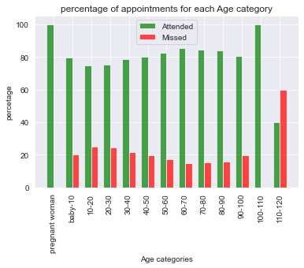

```python
percent_attended=one*100/df.groupby('Age categories')['Attendance'].count() #creating percentages
percent_missed=zero*100/df.groupby('Age categories')['Attendance'].count()
ind=np.arange(13)
width=.35
plt.bar(ind, percent_attended, width, color='green', alpha=.7, label='Attended'); #plotting them
plt.bar(ind + width, percent_missed, width, color='r', alpha=.7, label='Missed');
locations = ind + width / 2
labels =  ['pregnant woman', 'baby-10', '10-20', '20-30', '30-40',
                  '40-50', '50-60', '60-70', '70-80', '80-90', '90-100',
                  '100-110', '110-120'] ;
plt.xticks(locations, labels,rotation='vertical');
plt.xlabel('Age categories');
plt.ylabel('percetage');
plt.title('percentage of appointments for each Age category');
plt.legend();
```

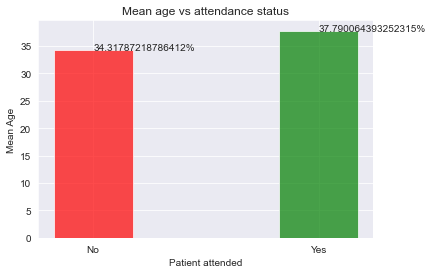

```python
locations=[0,1]
mean_age=df.groupby('Attendance')['Age'].mean().values
plt.bar(locations,mean_age,alpha=.7,width=.35,color=['r','g']); #plotting mean age for both categories of attendance.
plt.xlabel('Patient attended');
plt.ylabel('Mean Age');
for index, value in zip(locations,mean_age):
    plt.text(index,value,str(value)+"%")
plt.xticks(locations,['No','Yes']);
plt.title('Mean age vs attendance status');
```

> - The mean age of patients shows that slightly older patients tend to keep theri appoitments.

### Question 2: Is there any co-relation between the attendance and the medical condition of the person, that includes (Hipertension, Diabetes, Alcoholism, Handicap)?

### Question 3:Is reminding the patient with an SMS helps?

### Question 4: what effect does the scholarship have?

### Question 5:How different is the medical profile of people who attend and who don't?

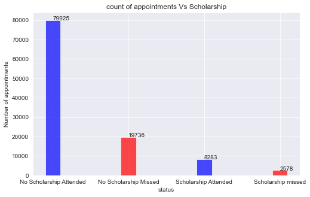

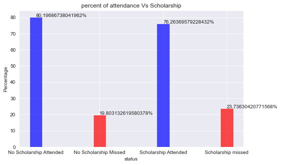

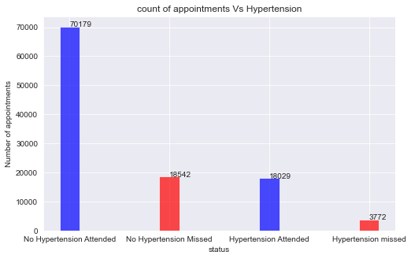

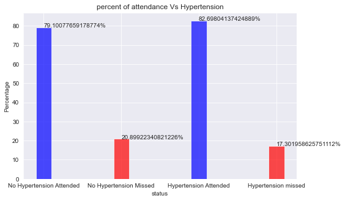

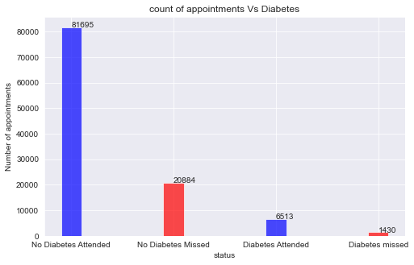

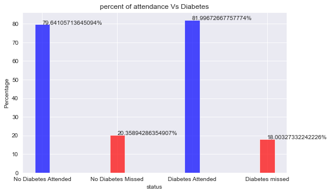

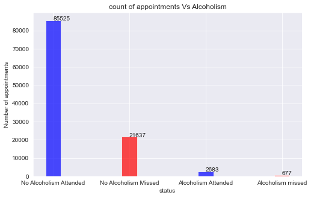

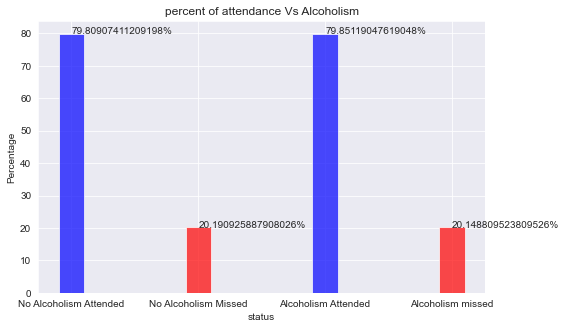

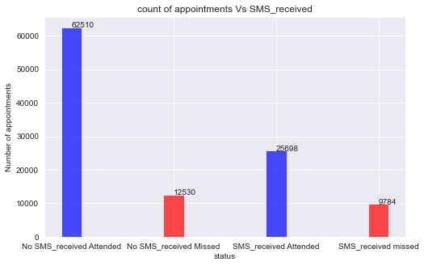

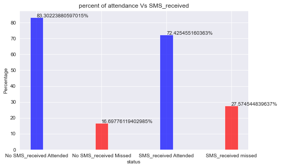

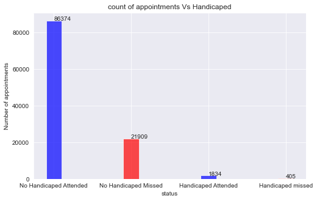

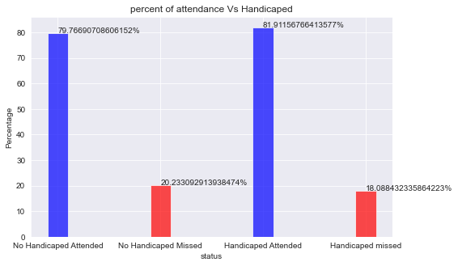

```python
inter=['Scholarship','Hypertension','Diabetes','Alcoholism','SMS_received','Handicaped'] #list of all interest columns.

for col in inter: #loop to plot graphs of counts and percentages.
    data=df.groupby(col)['Attendance'].value_counts()
    data_per=df.groupby(col)['Attendance'].value_counts(normalize=True)*100
    x_labels=['No '+col+' Attended','No '+col+' Missed',col+" Attended",col+" missed"]
    plt.figure(figsize=(8,5))
    plt.bar(x_labels ,data,color=['b','r','b','r'],alpha=.7,width=.2)
    plt.title('count of appointments Vs '+col)
    plt.xlabel('status')
    plt.ylabel('Number of appointments')
    for index, value in zip(x_labels,data.values):
        plt.text(index,value,str(value))

    plt.figure(figsize=(8,5))
    plt.bar(x_labels,data_per,color=['b','r','b','r'],alpha=.7,width=.2)
    plt.title('percent of attendance Vs '+col)
    plt.xlabel('status')
    plt.ylabel('Percentage')

    for index, value in zip(x_labels,data_per):
        plt.text(index,value,str(value)+"%")
```

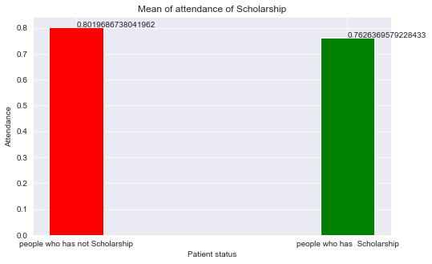

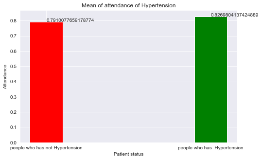

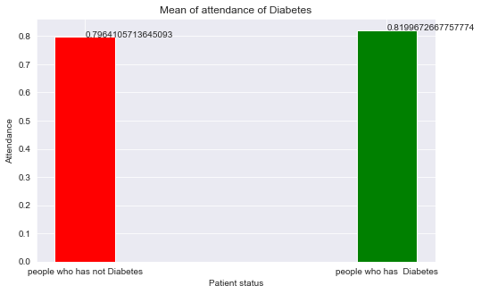

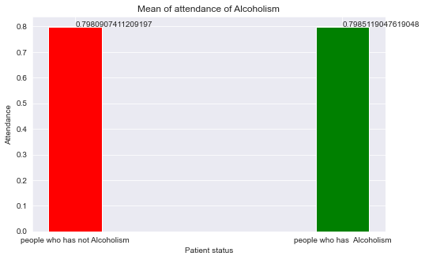

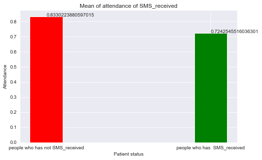

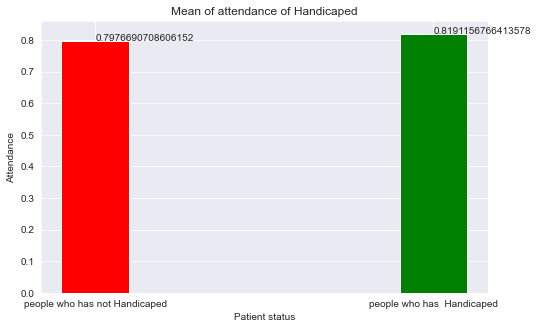

```python
inter=['Scholarship','Hypertension','Diabetes','Alcoholism','SMS_received','Handicaped']
i=1
for col in inter:#loop to plot means of attendance for people who had these characterstics.
    x=df.groupby(col)['Attendance'].mean().index
    y=df.groupby(col)['Attendance'].mean()
    plt.figure(figsize=(8,5))
    i+=1
    plt.bar(x,y,width=.2,color=['r','g'])
    plt.xlabel(col)
    plt.xticks(x,['people who has not '+col,'people who has  '+col])
    plt.ylabel('Attendance')
    plt.xlabel('Patient status')
    plt.title('Mean of attendance of '+col)
    for index, value in zip(x,y):
        plt.text(index,value,str(value))
```

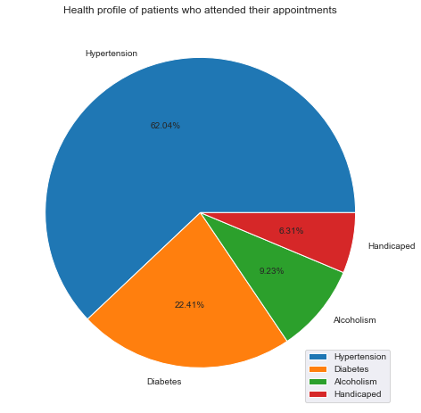

```python
sizes=[]
condition=['Hypertension','Diabetes','Alcoholism','Handicaped']
df1=df.query('Attendance== "1"') #dataframe of who attendedn.
for ii in condition: #loop to create the portion sizes of the pie chart.
    sizes.append(df1[ii].sum())
plt.figure(figsize=(8,8))
plt.pie(sizes,labels=condition,autopct='%1.2f%%');
plt.title('Health profile of patients who attended their appointments')
plt.legend();
```

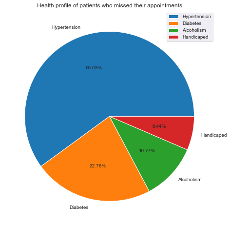

```python
sizes=[]
condition=['Hypertension','Diabetes','Alcoholism','Handicaped']
df2=df.query('Attendance== "0"')
for ii in condition: #loop to create the portion sizes of the pie chart.
    sizes.append(df2[ii].sum())
plt.figure(figsize=(8,8))
plt.pie(sizes,labels=condition,autopct='%1.2f%%');
plt.title('Health profile of patients who missed their appointments')
plt.legend();
```

### Question6: what effect does the duration between Scheduling and the actucal date have?

### Question7: does the day on which the appointment is scheduled make a difference?

### Question8: what effect does the Neighbourhood have?

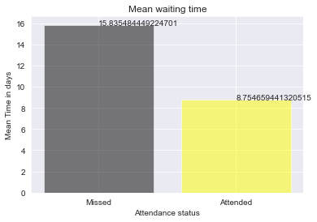

```python
waiting_data=df.groupby('Attendance')['WaitingTime'].mean()
locations=[0,1]
ax=plt.bar(locations,waiting_data,color=['black','yellow'],alpha=.5) #plotting mean wait time.
plt.xticks(locations,['Missed','Attended'])
plt.title('Mean waiting time')
plt.ylabel('Mean Time in days')
plt.xlabel('Attendance status')
for index, value in zip(locations,waiting_data):
    plt.text(index,value,str(value))
```

> Mean time of waiting is lower for people who attended their appointments.

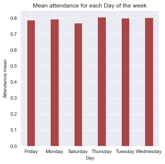

```python
plt.figure(figsize=(5,5))
x= df.groupby(['WeekDay'])['Attendance'].mean().index
y=df.groupby(['WeekDay'])['Attendance'].mean()
plt.bar(x,y,alpha=.7,width=.35,color='darkred'); #plotting mean attendance vs week day
plt.xticks(fontsize=10);
plt.title('Mean attendance for each Day of the week');
plt.xlabel('Day');
plt.ylabel('Attendance mean');
```

```python
df['WeekDay'].unique() #making sure there is't sundays.
```

```
array(['Friday', 'Tuesday', 'Monday', 'Wednesday', 'Thursday', 'Saturday'],
      dtype=object)
```

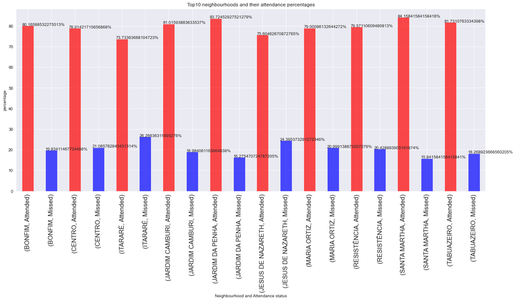

```python
top_places=df['Neighbourhood'].value_counts().index[:10] #getting the names of top 10 places by appointment counts.
plt.figure(figsize=(20,8))
top_places_df=df.copy().query('Neighbourhood in @top_places')
top_places_df.loc[:,'Attendance']=top_places_df['Attendance'].replace({1:'Attended',0:'Missed'}) # changing the values so that new values get plotted directly which improves reading.
top_places_df
places= top_places_df.groupby('Neighbourhood')['Attendance'].value_counts(normalize=True)*100
ax= places.plot(kind='bar',alpha=.7,width=.5,color=['red','blue']) #plotting percentages of attendance and missing for each neighbourhood.
plt.xticks(fontsize=15);
plt.xlabel('Neighbourhood and Attendance status')
plt.ylabel('percentage')
plt.title('Top10 neighbourhoods and their attendance percentages')
for p in ax.patches:
    ax.annotate(str((p.get_height()))+'%', xy=(p.get_x(), p.get_height()))
```

## Conclusions

Number of patients attended their appointments is higher than who missed by around 4 folds.

Females has the larger number of appointments, Males tend to attend appoinments more, but with slight margin over females.

Mean attendance for the pregnant woman and the group from 100-110 is one due to the lack of data (only one pregnant woman).

The distribution of means in the middle shows that from ages 10 to 70 people tend not to miss this appointments more as they grow up, then the means falls as they get pass 70.

People with a scholarship constitute a small portion tend to have lower attendance mean.

people suffering from hypertension or diabetes or Handicaped are also a small portion of the data but they have slightly higher attendance mean.

Receiving an SMS reminder has lower the attendance mean.

the health profile of people who attend is somehow identical to those who miss.

Mean time of waiting is lower for people who attended their appointments.

No appointments on Sundays, mean attendane across the week seems equal, with slightly lower attendance mean on Saturdays.

For top 10 neighbourhoods in terms of appointments count, attendance percentages does not seem to be affected by the place.

### Limitations:

1- appointments are scheduled over short span of time, this limited understanding the effect of seasons, holidays on the showing up of patients.  
2- Some data about the distance between the patient and the neighbourhood would be useful.  
3- indications of the seriousness of illness would be helpful too.  
4-Dataset is missing key informations like the prices, employment status of patients.  
5- for some cases there is small number of people reported such as (one pregnant woman, small number of alchoholics), this somehow limited the analysis.